# IE 360 HW1

## BASIC DATA ANALYSIS AND RELATED GOOGLE TRENDS SEARCH

##### Oguzhan Pinar - IE360 HW1 - Fall 2020

```python
#Import Required Libraries

import pandas as pd
import numpy as np
import datetime as dt
import matplotlib.pyplot as plt
import seaborn as sns
import investpy
```

# 1. Stock price changes vs financial words' popularity:

Firstly, I will analyze leading Turkish stock price index (BIST 100) and popularity of finance related words on google.

### 1.1. Analyze BIST 100 data

I will use closing prices of BIST 100 index for last 6 months. Also, I will use daily data because in Turkey we experience some daily unstability in economy and I believe that on those days "BORSA ISTANBUL" fluctuates enourmusly and most people are interested in those economical unstabilities in Turkey. Therefore, financial fluctuations and trends of finance related words might be moving together for those days.

```python
bist_100 = investpy.get_index_historical_data(index='BIST 100',
                                        country='turkey',
                                       from_date = "29/05/2020",
                                       to_date="17/11/2020")
bist_100.head()
```

| Date | Open | High | Low | Close | Volume | Currency |
| --- | --- | --- | --- | --- | --- | --- |
| 2020-05-29 | 1051.83 | 1056.69 | 1046.71 | 1055.20 | 2853692928 | TRY |
| 2020-06-01 | 1064.81 | 1073.72 | 1063.57 | 1072.66 | 2844257536 | TRY |
| 2020-06-02 | 1077.88 | 1084.84 | 1070.99 | 1080.97 | 3033728256 | TRY |
| 2020-06-03 | 1089.26 | 1092.31 | 1083.27 | 1091.11 | 2896278784 | TRY |
| 2020-06-04 | 1093.84 | 1098.53 | 1087.79 | 1095.37 | 2917456384 | TRY |

For my analysis I will use returns of BIST 100 index. To get the returns, I will calculate the percentage changes in closing prices of BIST 100 index from 29/05/2020 to 17/11/2020.

```python
bist_100_cl = pd.DataFrame(bist_100.Close)
the_changes = pd.DataFrame((bist_100_cl.iloc[1:,0].reset_index(drop=True) -
                            bist_100_cl.iloc[:len(bist_100_cl)-1,0].reset_index(drop=True)) /
                           bist_100_cl.iloc[1:,0].reset_index(drop=True))

bist_100_returns = pd.DataFrame(the_changes)
bist_100_returns.index = bist_100_cl.iloc[1:].index
bist_100_returns.columns = ["return"]
bist_100_returns
```

| Date | return |
| --- | --- |
| 2020-06-01 | 0.016277 |
| 2020-06-02 | 0.007688 |
| 2020-06-03 | 0.009293 |
| 2020-06-04 | 0.003889 |
| 2020-06-05 | 0.004408 |
| ... | ... |
| 2020-11-11 | 0.028314 |
| 2020-11-12 | -0.005874 |
| 2020-11-13 | 0.015132 |
| 2020-11-16 | 0.001315 |
| 2020-11-17 | -0.026411 |

118 rows × 1 columns

Now plot the histogram of the data for each month. To make the visual inspection easier, I will keep the x axis shared for each months.

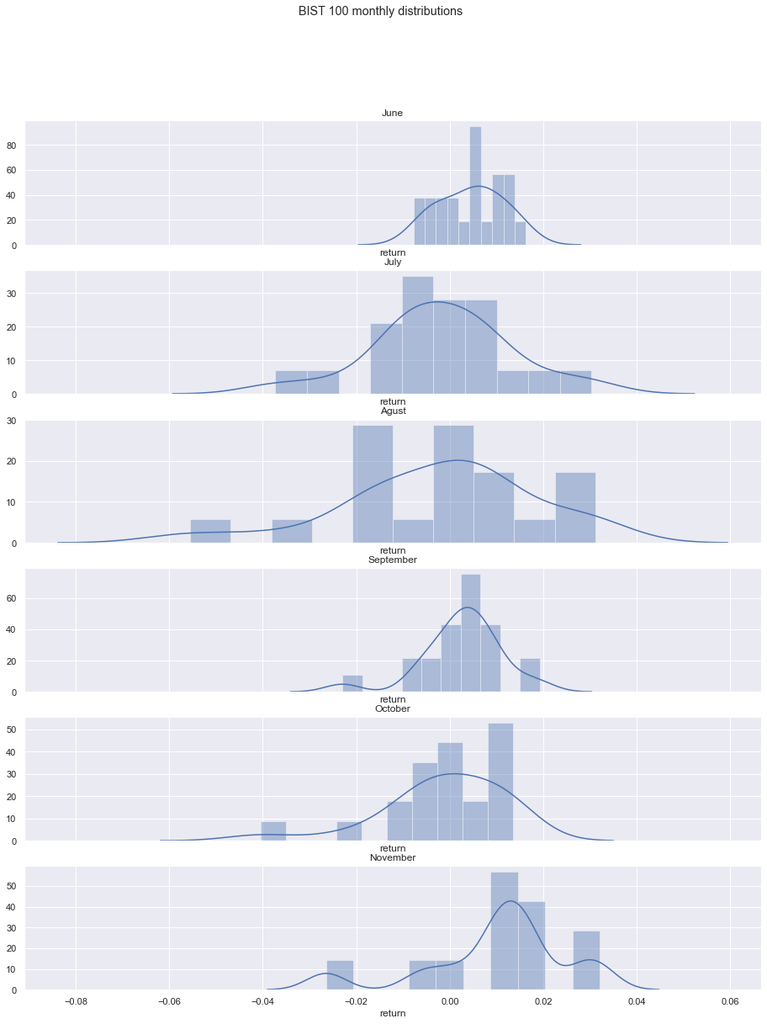

```python
# first seperate the data of each month

bist_100_jun = bist_100_returns[ bist_100_returns.index < dt.datetime(2020,7,1)]
bist_100_jul = bist_100_returns[(bist_100_returns.index >= dt.datetime(2020,7,1)) & (bist_100_returns.index < dt.datetime(2020,8,1))]
bist_100_agu = bist_100_returns[(bist_100_returns.index >= dt.datetime(2020,8,1)) & (bist_100_returns.index < dt.datetime(2020,9,1))]
bist_100_sep = bist_100_returns[(bist_100_returns.index >= dt.datetime(2020,9,1)) & (bist_100_returns.index < dt.datetime(2020,10,1))]
bist_100_oct = bist_100_returns[(bist_100_returns.index >= dt.datetime(2020,10,1)) & (bist_100_returns.index < dt.datetime(2020,11,1))]
bist_100_nov = bist_100_returns[(bist_100_returns.index >= dt.datetime(2020,11,1)) & (bist_100_returns.index < dt.datetime(2020,12,1))]

#Plotting each months on a same figure with sharing x axis

sns.set(rc={'figure.figsize':(15.7,19)})

fig, axs = plt.subplots(6,1, sharex=True)
fig.suptitle('BIST 100 monthly distributions')

sns.distplot(bist_100_jun["return"], bins = 10, ax = axs[0])
sns.distplot(bist_100_jul["return"], bins = 10, ax = axs[1])
sns.distplot(bist_100_agu["return"], bins = 10, ax = axs[2])
sns.distplot(bist_100_sep["return"], bins = 10, ax = axs[3])
sns.distplot(bist_100_oct["return"], bins = 10, ax = axs[4])
sns.distplot(bist_100_nov["return"], bins = 10, ax = axs[5])

axs[0].set_title("June")
axs[1].set_title("July")
axs[2].set_title("Agust")
axs[3].set_title("September")
axs[4].set_title("October")
axs[5].set_title("November")
```

First of all we should keep in mind that we are analyzing the returns of BIST 100 index here. Therefore, those distributions can show 1. could long term investers make profit at the month (mean), 2. volatility of returns (st. dev.), 3. impacts of outlier returns (skewness). Now my comments for each month are:

1. June:
   - We observe positive mean for returns; therefore, investing long term on BIST 100 was profitable in June.
   - In terms of volatility the best month is June. Because we observe all returns are close to each other and therefore have small variance which provides for an asset to be less risky and more predictable.
   - There is no obvious skewness for June, therefore, we would not experienced suprise (unusual positive or negative returns) if we had invested on BIST 100 in June.
2. July:
   - We see negative mean in July; therefore, long term investors of BIST 100 have lost money.
   - There is high variance in July; therefore, the stocks were very volatile.
   - There is no obvious skewness for also July.
3. Agust:
   - The mean is positive for Agust. Meaning that it was a profitable month.
   - In Agust BIST 100 experienced the highest variance i.e. volatility.
   - The distribution is obviously left skewed; therefore, investors have experienced bas suprises (big falls) in Agust. The worst return (-5%) of the 6 months period is experienced in Agust
4. September:
   - There is positive mean i.e. positive profit.
   - There is low variance compared the other months. Meaning that it was not very risky to invest on BIST 100. However,
   - BIST 100 experienced left skewed distribution meaning that in some days investors lost big rates.
5. October:
   - It seems to be 0 mean in October.
   - The variance is not too bad but,
   - It has terrible left skewness. Therefore, the investors must have lost too much money on BIST 100.
6. November:
   - For November, BIST 100 has experienced the best mean returns.
   - Even though, we have less data for November, we can observe the volatility.
   - It seems that we are going to have left skewed data for November.

Now I will continue with related google trends analysis.

### 1.2. Determine the Words

As the third step of the analysis, I need to choose which words I will use. The first potential word is "borsa". Since I will be looking stock prices data, the closest relationship should be with "borsa" word. However, since we will be looking google trends data, it will represent the popularity among household in Turkey because it would not be rational to expect traders to use google to check the stock prices. Therefore, we can expect "dolar" and "altın" may represent financial fluctuations better as we are going to see in the analysis below.

To do the analysis of the words, I will first import data from google trends and clean the data in the code chunk below:

```python
# Import the google trends data for the words "borsa", "dolar", "altin"
goog_fin = pd.read_csv("https://trends.google.com/trends/api/widgetdata/multiline/csv?req=%7B%22time%22%3A%222020-06-01%202020-11-20%22%2C%22resolution%22%3A%22DAY%22%2C%22locale%22%3A%22tr%22%2C%22comparisonItem%22%3A%5B%7B%22geo%22%3A%7B%22country%22%3A%22TR%22%7D%2C%22complexKeywordsRestriction%22%3A%7B%22keyword%22%3A%5B%7B%22type%22%3A%22BROAD%22%2C%22value%22%3A%22dolar%22%7D%5D%7D%7D%2C%7B%22geo%22%3A%7B%22country%22%3A%22TR%22%7D%2C%22complexKeywordsRestriction%22%3A%7B%22keyword%22%3A%5B%7B%22type%22%3A%22BROAD%22%2C%22value%22%3A%22alt%C4%B1n%22%7D%5D%7D%7D%2C%7B%22geo%22%3A%7B%22country%22%3A%22TR%22%7D%2C%22complexKeywordsRestriction%22%3A%7B%22keyword%22%3A%5B%7B%22type%22%3A%22BROAD%22%2C%22value%22%3A%22borsa%22%7D%5D%7D%7D%5D%2C%22requestOptions%22%3A%7B%22property%22%3A%22%22%2C%22backend%22%3A%22IZG%22%2C%22category%22%3A0%7D%7D&token=APP6_UEAAAAAX7hGPjMarDUNHDKCcdK5_PlS2ZWQdRaM&tz=-180")
goog_fin = goog_fin.reset_index()
goog_fin.columns = goog_fin.iloc[0]
goog_fin = goog_fin.drop(0)
goog_fin = goog_fin.set_index("Day")
goog_fin = goog_fin.astype(int)
goog_fin
```

| Day | dolar: (Turkey) | altın: (Turkey) | borsa: (Turkey) |
| --- | --- | --- | --- |
| 2020-06-01 | 13 | 17 | 3 |
| 2020-06-02 | 14 | 18 | 3 |
| 2020-06-03 | 14 | 21 | 3 |
| 2020-06-04 | 13 | 20 | 3 |
| 2020-06-05 | 12 | 20 | 3 |
| ... | ... | ... | ... |
| 2020-11-14 | 34 | 24 | 1 |
| 2020-11-15 | 25 | 19 | 1 |
| 2020-11-16 | 37 | 35 | 3 |
| 2020-11-17 | 30 | 29 | 3 |
| 2020-11-18 | 26 | 26 | 3 |

171 rows × 3 columns

I will check the plots and correlations of them, to see if they are moving together or not.

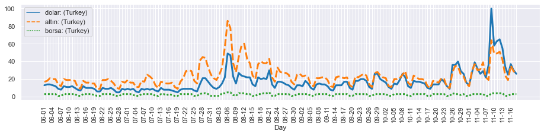

```python
#Set the figure size:
sns.set(rc={'figure.figsize':(15.7,3)})

#Draw the lineplots of the data:
goog_fin_plt = sns.lineplot(data=goog_fin, palette="tab10", linewidth=3)

#Create labels for data and rotate them:
my_labels = goog_fin.reset_index().apply(lambda x: x.Day[-5:], axis=1)
for i in range(len(my_labels)):
    if (i % 3 != 0 ):
        my_labels[i] = ""

goog_fin_plt.set_xticklabels(rotation=90, labels=my_labels)

goog_fin_plt
```

```python
goog_fin.corr()
```

| 0 | dolar: (Turkey) | altın: (Turkey) | borsa: (Turkey) |
| --- | --- | --- | --- |
| dolar: (Turkey) | 1.000000 | 0.742403 | 0.485202 |
| altın: (Turkey) | 0.742403 | 1.000000 | 0.685599 |
| borsa: (Turkey) | 0.485202 | 0.685599 | 1.000000 |

```python
np.std(goog_fin["altın: (Turkey)"]), np.std(goog_fin["dolar: (Turkey)"])
```

```
(12.426076340054033, 12.50763864959179)
```

As seen in the plots and correlation table above both "dolar" "altin" and "borsa" moving together. However, as I have stated the word "borsa" is less popular than others and its fluctuations are not as obvious as others. There is not too much difference between "dolar" and "altin". I will continue with "altın" since its fluctuations are more visible.

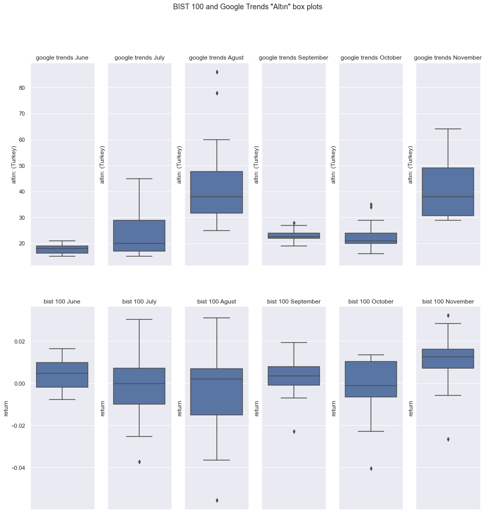

```python
goog_gold = pd.DataFrame(goog_fin["altın: (Turkey)"])
bist_and_gold_pop = bist_100_returns.merge(pd.DataFrame(goog_gold), how="left", left_index=True, right_index=True)
goog_gold = pd.DataFrame(bist_and_gold_pop[["altın: (Turkey)"]])
# first seperate google trends data of each month

goog_gold_jun = goog_gold[ goog_gold.index < "2020-7-1"]
goog_gold_jul = goog_gold[(goog_gold.index >= dt.datetime(2020,7,1)) & (goog_gold.index < dt.datetime(2020,8,1))]
goog_gold_agu = goog_gold[(goog_gold.index >= dt.datetime(2020,8,1)) & (goog_gold.index < dt.datetime(2020,9,1))]
goog_gold_sep = goog_gold[(goog_gold.index >= dt.datetime(2020,9,1)) & (goog_gold.index < dt.datetime(2020,10,1))]
goog_gold_oct = goog_gold[(goog_gold.index >= dt.datetime(2020,10,1))& (goog_gold.index < dt.datetime(2020,11,1))]
goog_gold_nov = goog_gold[(goog_gold.index >= dt.datetime(2020,11,1))& (goog_gold.index < dt.datetime(2020,12,1))]

#Plotting each months on a same figure with sharing x axis

sns.set(rc={'figure.figsize':(15.7,16)})

fig, axs = plt.subplots(2,6, sharey="row")
fig.suptitle('BIST 100 and Google Trends "Altın" box plots')

sns.boxplot(goog_gold_jun["altın: (Turkey)"], orient = "v", ax = axs[0,0])
sns.boxplot(goog_gold_jul["altın: (Turkey)"], orient = "v", ax = axs[0,1])
sns.boxplot(goog_gold_agu["altın: (Turkey)"], orient = "v", ax = axs[0,2])
sns.boxplot(goog_gold_sep["altın: (Turkey)"], orient = "v", ax = axs[0,3])
sns.boxplot(goog_gold_oct["altın: (Turkey)"], orient = "v", ax = axs[0,4])
sns.boxplot(goog_gold_nov["altın: (Turkey)"], orient = "v", ax = axs[0,5])

axs[0, 0].set_title("google trends June")
axs[0, 1].set_title("google trends July")
axs[0, 2].set_title("google trends Agust")
axs[0, 3].set_title("google trends September")
axs[0, 4].set_title("google trends October")
axs[0, 5].set_title("google trends November")


sns.boxplot(bist_100_jun["return"], orient = "v", ax = axs[1,0])
sns.boxplot(bist_100_jul["return"], orient = "v", ax = axs[1,1])
sns.boxplot(bist_100_agu["return"], orient = "v", ax = axs[1,2])
sns.boxplot(bist_100_sep["return"], orient = "v", ax = axs[1,3])
sns.boxplot(bist_100_oct["return"], orient = "v", ax = axs[1,4])
sns.boxplot(bist_100_nov["return"], orient = "v", ax = axs[1,5])

axs[1, 0].set_title("bist 100 June")
axs[1, 1].set_title("bist 100 July")
axs[1, 2].set_title("bist 100 Agust")
axs[1, 3].set_title("bist 100 September")
axs[1, 4].set_title("bist 100 October")
axs[1, 5].set_title("bist 100 November")
```

From the box plots we can make the same observations as we did from the distributions. In addition to that, we see that bist 100 and popularity of "altın" word on google have parallel variances. Meaning that increasing volatility in BIST 100 returns and people's google search for gold prices are moving together.

I would also like to include lineplots of them to see their movements and peak times in one plot. To observe volatility of BIST 100 vs popularity of gold price search, I should take the absolute value of returns also to get better visual results I will multiply BIST 100 returns with 1000:

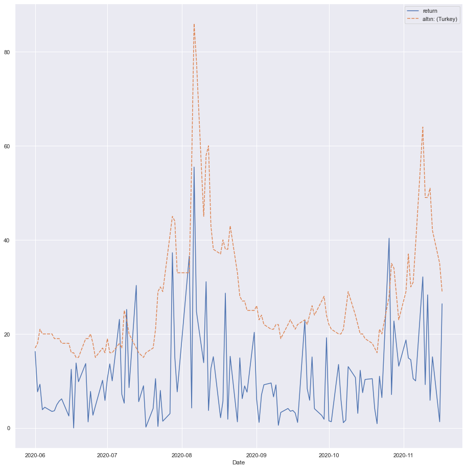

```python
bist_and_gold_pop = bist_100_returns.merge(pd.DataFrame(goog_gold), how="left", left_index=True, right_index=True)
bist_and_gold_pop["return"] = abs(bist_and_gold_pop["return"])*1000
sns.lineplot(data=bist_and_gold_pop)
```

We can clearly see in the line plot that, during high volatile days of BIST100 index, searching for gold prices in Turkey is also increasing.